# Influence of redox potential on bacterial protein evolution (2023)

This vignette runs the code to make the plots from the following paper:

> Dick JM, Meng D. 2023. Community- and genome-based evidence for a shaping influence of redox potential on bacterial protein evolution. *mSystems* **8**(3): e00014-23. doi: 10.1128/msystems.00014-23

**Post-publication update** on 2024-07-10: The reference database for constructing community reference proteomes has been changed from RefSeq 206 to GTDB 220. Likewise, taxonomic classifications now use [RDP Classifier training files for 16S rRNA sequences from GTDB](https://doi.org/10.5281/zenodo.12703477) instead of the default RDP Classifier training set. This update affects the results shown in the plots (except for Fig. 4) but in most cases does not change the basic trends. The slope in Fig. 2b is now negative instead of positive, but the 95% confidence interval still contains zero. The number of samples with classifications for archaeal communities after filtering increased by more than 100, and the slope for Archaea in Fig. 6b is now significantly positive instead of non-significantly negative.

This vignette was compiled on 2025-05-20 with **JMDplots** 1.2.22 and **chem16S** 1.2.0.

```r
library(JMDplots)
```

## Thermodynamic model for the relationship between carbon oxidation state of reference proteomes and redox potential (Figure 1)

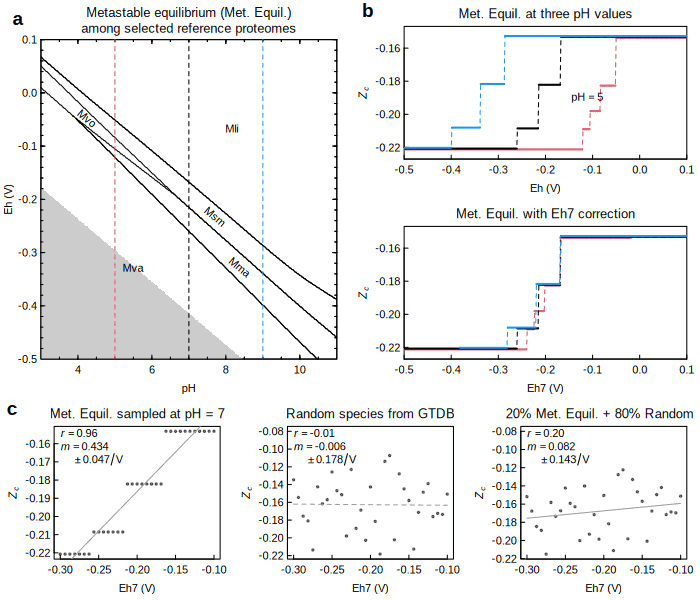

```r
orp16S_1()
```

## *Z*<sub>C</sub> of reference proteomes compared with oxygen tolerance and with metaproteomes (Figure 2)

```r
orp16S_2()
```

```
## [1] "75 genera not matched to GTDB"
## [1] "Archaeal genera: Methanobrevibacter_A Methanosphaera"
```

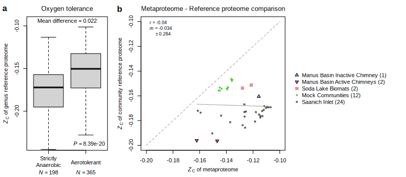

**Data sources:** List of strictly anaerobic and aerotolerant genera (Million and Raoult, 2018), Metaproteomes: Manus Basin Inactive Chimney (Meier et al., 2019), Manus Basin Active Chimneys (Pjevac et al., 2018), Soda Lake Biomats (Kleiner et al., 2017), Mock Communities (Kleiner et al., 2017), Saanich Inlet (Hawley et al., 2017).

## Methods overview and chemical depth profiles in Winogradsky columns (Figure 3)

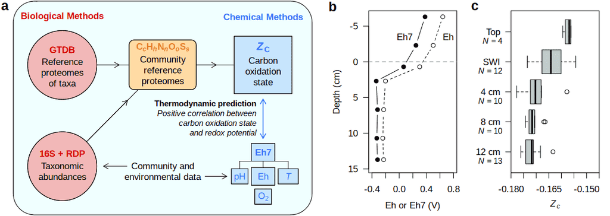

```r
orp16S_3()
```

**Data sources:** **(b)** ORP and pH (Diez-Ercilla et al., 2019) to calculate Eh7. **(c)** 16S rRNA gene sequences (Rundell et al., 2014) to calculate *Z*<sub>C</sub>.

## Sample locations on world map and Eh-pH diagram (Figure 4)

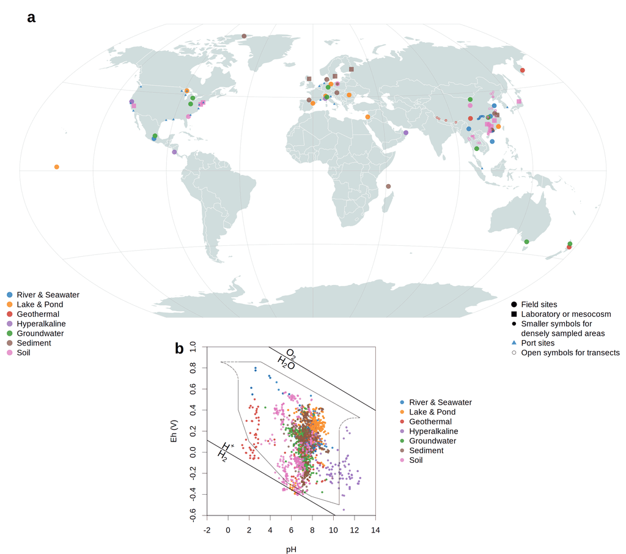

```r
orp16S_4()
```

**Data sources:** **(a)** coastlineWorld dataset in R package oce (Kelley and Richards, 2022); shapefiles for North American Great Lakes (USGS, 2010). **(b)** Outline is from Baas Becking et al. (1960).

## Associations between Eh7 and *Z*<sub>C</sub> at local scales (Figure 5)

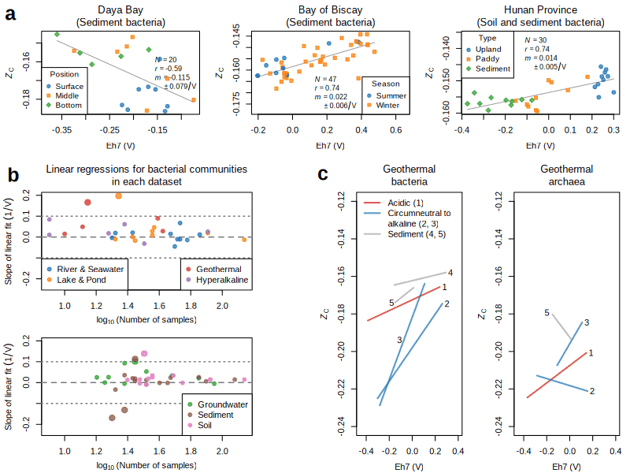

```r
orp16S_5()
```

**Data sources:** **(a)** Daya Bay (Wu et al., 2021), Bay of Biscay (Lanzén et al., 2021), Hunan Province (Meng et al., 2019). **(c)** **1** acidic and **2** circumneutral to alkaline New Zealand hot springs (Power et al., 2018), **3** Eastern Tibetan Plateau (Guo et al., 2020), **4** Uzon Caldera (Peltek et al., 2020), **5** Southern Tibetan Plateau (Ma et al., 2021).

## Tally of regression slopes and binomial *p*-values (Table 1a)

```r
colnames <- c("Ntot", "Npos", "Nneg", "p")
kable(orp16S_T1(), col.names = rep(colnames, 2)) %>%
  add_header_above(c(" " = 1, "Bacteria" = 4, "Archaea" = 4))
```

|  | Bacteria Ntot | Bacteria Npos | Bacteria Nneg | Bacteria p | Archaea Ntot | Archaea Npos | Archaea Nneg | Archaea p |
| --- | --- | --- | --- | --- | --- | --- | --- | --- |
| River & Seawater | 10 | 5 | 5 | 0.62300 | 4 | 3 | 1 | 0.313 |
| Lake & Pond | 9 | 6 | 3 | 0.25400 | 3 | 1 | 2 | 0.875 |
| Geothermal | 5 | 5 | 0 | 0.03100 | 4 | 2 | 2 | 0.688 |
| Hyperalkaline | 6 | 5 | 1 | 0.10900 | 3 | 2 | 1 | 0.500 |
| Groundwater | 10 | 7 | 3 | 0.17200 | 6 | 2 | 4 | 0.891 |
| Sediment | 16 | 10 | 6 | 0.22700 | 6 | 4 | 2 | 0.344 |
| Soil | 12 | 9 | 3 | 0.07300 | 5 | 2 | 3 | 0.812 |
| Total | 68 | 47 | 21 | 0.00109 | 31 | 16 | 15 | 0.500 |

## Tally of regression slopes with same sign of minimum and maximum values in 95% confidence interval (Table 1b)

```r
colnames <- c("Ntot", "Npos", "Nneg", "p")
kable(orp16S_T1(samesign = TRUE), col.names = rep(colnames, 2)) %>%
  add_header_above(c(" " = 1, "Bacteria" = 4, "Archaea" = 4))
```

|  | Bacteria Ntot | Bacteria Npos | Bacteria Nneg | Bacteria p | Archaea Ntot | Archaea Npos | Archaea Nneg | Archaea p |
| --- | --- | --- | --- | --- | --- | --- | --- | --- |
| River & Seawater | 2 | 2 | 0 | 0.250 | 2 | 2 | 0 | 0.25000 |
| Lake & Pond | 5 | 4 | 1 | 0.187 | 3 | 1 | 2 | 0.87500 |
| Geothermal | 2 | 2 | 0 | 0.250 | 1 | 1 | 0 | 0.50000 |
| Hyperalkaline | 4 | 4 | 0 | 0.062 | 0 | 0 | 0 | NA |
| Groundwater | 5 | 5 | 0 | 0.031 | 2 | 1 | 1 | 0.75000 |
| Sediment | 9 | 6 | 3 | 0.254 | 4 | 2 | 2 | 0.68800 |
| Soil | 7 | 7 | 0 | 0.008 | 3 | 2 | 1 | 0.50000 |
| Total | 34 | 30 | 4 | 0.000 | 15 | 9 | 6 | 0.30362 |

## Associations between Eh7 and *Z*<sub>C</sub> at a global scale (Figure 6)

```r
global.slopes <- orp16S_6()
```

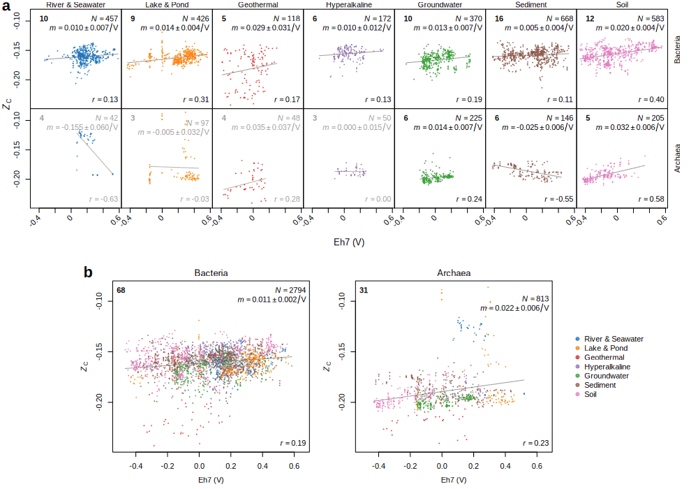

## Comparison of Eh7, Eh, and O<sub>2</sub> as predictors of carbon oxidation state (Figure S2)

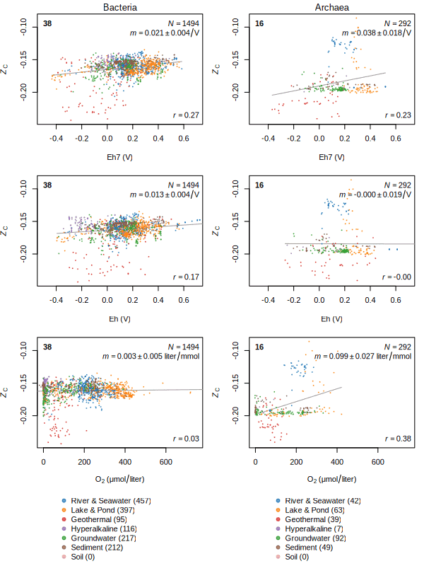

```r
orp16S_S2()
```

## Global analysis including only datasets using 515F/806R primers from the Earth Microbiome Project (EMP) (Figure S3)

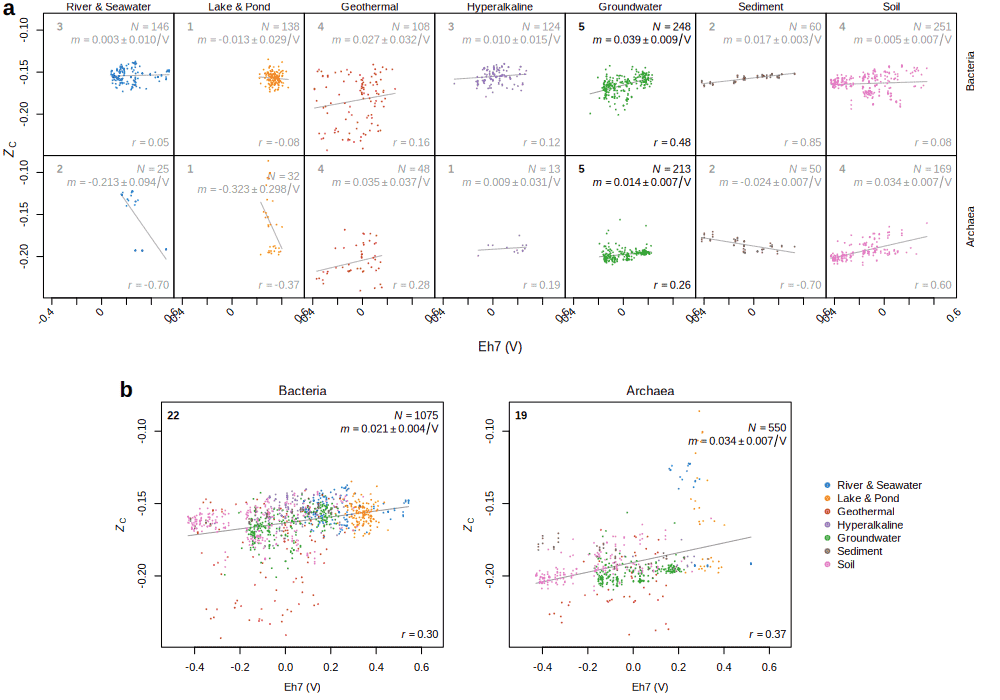

```r
orp16S_6(EMP_primers = TRUE)
```

## Genus-level taxonomic classifications (using 16S rRNA sequences from GTDB) mapped to the GTDB taxonomy

**NOTE**: With the switch to GTDB on both ends, this shows 100% mapping rate, higher than the values mentioned in the article for classifications from the RDP training set mapped to the NCBI taxonomy.

```r
# Read Dataset S3 (created by orp16S_D3())
dat <- read.csv(system.file("extdata/orp16S/Dataset_S3.csv", package = "JMDplots"))
perc_bac <- round(mean(subset(dat, lineage == "Bacteria")$mapperc))
perc_arc <- round(mean(subset(dat, lineage == "Archaea")$mapperc))
message(paste0(perc_bac, "% for bacteria, ", perc_arc, "% for archaea"))
```

```
## 100% for bacteria, 100% for archaea
```

## References

Baas Becking LGM, Kaplan IR, Moore D. 1960. Limits of the natural environment in terms of pH and oxidation-reduction potentials. *The Journal of Geology* **68**(3): 243–284. doi: 10.1086/626659

Diez-Ercilla M, Falagán C, Yusta I, Sánchez-España J. 2019. Metal mobility and mineral transformations driven by bacterial activity in acidic pit lake sediments: Evidence from column experiments and sequential extraction. *Journal of Soils and Sediments* **19**(3): 1527–1542. doi: 10.1007/s11368-018-2112-2

Guo L, Wang G, Sheng Y, Sun X, Shi Z, Xu Q, Mu W. 2020. Temperature governs the distribution of hot spring microbial community in three hydrothermal fields, Eastern Tibetan Plateau Geothermal Belt, Western China. *Science of The Total Environment* **720**: 137574. doi: 10.1016/j.scitotenv.2020.137574

Hawley AK, Torres-Beltrán M, Zaikova E, Walsh DA, Mueller A, Scofield M, Kheirandish S, Payne C, Pakhomova L, Bhatia M, et al. 2017. A compendium of multi-omic sequence information from the Saanich Inlet water column. *Scientific Data* **4**(1): 170160. doi: 10.1038/sdata.2017.160

Kelley D, Richards C. 2022. *oce: Analysis of Oceanographic Data*. Available at https://cran.r-project.org/package=oce.

Kleiner M, Thorson E, Sharp CE, Dong X, Liu D, Li C, Strous M. 2017. Assessing species biomass contributions in microbial communities via metaproteomics. *Nature Communications* **8**(1): 1558. doi: 10.1038/s41467-017-01544-x

Lanzén A, Mendibil I, Borja Á, Alonso-Sáez L. 2021. A microbial *mandala* for environmental monitoring: Predicting multiple impacts on estuarine prokaryote communities of the Bay of Biscay. *Molecular Ecology* **30**(13): 2969–2987. doi: 10.1111/mec.15489

Ma L, Wu G, Yang J, Huang L, Phurbu D, Li W-J, Jiang H. 2021. Distribution of hydrogen-producing bacteria in Tibetan hot springs, China. *Frontiers in Microbiology* **12**: 1789. doi: 10.3389/fmicb.2021.569020

Meier DV, Pjevac P, Bach W, Markert S, Schweder T, Jamieson J, Petersen S, Amann R, Meyerdierks A. 2019. Microbial metal-sulfide oxidation in inactive hydrothermal vent chimneys suggested by metagenomic and metaproteomic analyses. *Environmental Microbiology* **21**(2): 682–701. doi: 10.1111/1462-2920.14514

Meng D, Li J, Liu T, Liu Y, Yan M, Hu J, Li X, Liu X, Liang Y, Liu H, et al. 2019. Effects of redox potential on soil cadmium solubility: Insight into microbial community. *Journal of Environmental Sciences* **75**: 224–232. doi: 10.1016/j.jes.2018.03.032

Million M, Raoult D. 2018. Linking gut redox to human microbiome. *Human Microbiome Journal* **10**: 27–32. doi: 10.1016/j.humic.2018.07.002

Peltek SE, Bryanskaya AV, Uvarova YE, Rozanov AS, Ivanisenko TV, Ivanisenko VA, Lazareva EV, Saik OV, Efimov VM, Zhmodik SM, et al. 2020. Young «oil site» of the Uzon Caldera as a habitat for unique microbial life. *BMC Microbiology* **20**(2): 349. doi: 10.1186/s12866-020-02012-1

Pjevac P, Meier DV, Markert S, Hentschker C, Schweder T, Becher D, Gruber-Vodicka HR, Richter M, Bach W, Amann R, et al. 2018. Metaproteogenomic profiling of microbial communities colonizing actively venting hydrothermal chimneys. *Frontiers in Microbiology* **9**: 680. doi: 10.3389/fmicb.2018.00680

Power JF, Carere CR, Lee CK, Wakerley GLJ, Evans DW, Button M, White D, Climo MD, Hinze AM, Morgan XC, et al. 2018. Microbial biogeography of 925 geothermal springs in New Zealand. *Nature Communications* **9**(1): 2876. doi: 10.1038/s41467-018-05020-y

Rundell EA, Banta LM, Ward DV, Watts CD, Birren B, Esteban DJ. 2014. 16S rRNA gene survey of microbial communities in Winogradsky columns. *PLOS One* **9**(8): e104134. doi: 10.1371/journal.pone.0104134

USGS. 2010. Great Lakes and Watersheds Shapefiles. U.S. Geological Survey. Available at https://www.sciencebase.gov/catalog/item/530f8a0ee4b0e7e46bd300dd.

Wu J, Hong Y, Liu X, Hu Y. 2021. Variations in nitrogen removal rates and microbial communities over sediment depth in Daya Bay, China. *Environmental Pollution* **286**: 117267. doi: 10.1016/j.envpol.2021.117267